# Sales data analysis

2023-02-15

## Dataframe operation

Import the common frameworks

```r
library(tidyverse)
```

```r
library(ggplot2)
```

### Read and write csv

Read the csv files

```r
df_sales = read.csv("./sales_data_sample.csv")
```

Create a csv file named `sales_data_sample_backup.csv` with the data in `df_sales`

```r
# write.csv(df_sales, "sales_data_sample_backup.csv")
```

### Joins

left_join: perform a left join of two data frames based on a common variable

```r
# create two data frames
df1 <- data.frame(id = c(1, 2, 3), name = c("Alice", "Bob", "Charlie"))
df2 <- data.frame(id = c(2, 3, 4), age = c(25, 30, 35))
df3 <- data.frame(id = c(2, 3, 4), age = c(25, 30, 35))

df4 <- df1 %>% left_join(df2, by = "id") %>% left_join(df3, by = "id")

df4 <- df1 %>% inner_join(df2, by = "id") %>% left_join(df3, by = "id")
```

### Access and update the data frame column values

```r
# Get the column (PRODUCTLINE) values from dataframe (df_sales)
df_productline <- df_sales$PRODUCTLINE

### Update the DEALSIZE values from Small, Medium, Large to S, M, L respectively
df_sales$DEALSIZE <- ifelse(
  df_sales$DEALSIZE == "Small",
  "S",
  ifelse(
    df_sales$DEALSIZE == "Medium",
    "M",
    ifelse(
      df_sales$DEALSIZE == "Large",
      "L",
      NA
    )
  )
)

# Check if there is a value on DEALSIZE other than S, M, L
any(is_null(df_sales$DEALSIZE))
```

```
## [1] FALSE
```

```r
# Extract the column value of "DEALSIZE" in second row
df_sales[2, "DEALSIZE"]
```

```
## [1] "S"
```

### Aggregation

In most of cases, we can use `groupby` and `summarize` function to analyze the datasets

```r
df_sales %>%
  group_by(PRODUCTLINE) %>%      # Group the data by the column "PRODUCTLINE"
  summarize(
    count = n(),                 # Number of rows in each product line
    sum_quantity_ordered = sum(QUANTITYORDERED),
    mean_quantity_ordered = mean(QUANTITYORDERED),
    sd_quantity_ordered = sd(QUANTITYORDERED), # Standard Deviation
    min_quantity_ordered = min(QUANTITYORDERED),
    max_quantity_ordered = max(QUANTITYORDERED),
    median_quantity_ordered = median(QUANTITYORDERED),
    unique_country_per_productline = length(unique(COUNTRY)), # Get the unqiue country count per product line
    unique_country_per_productline_by_n_distinct = n_distinct(COUNTRY),
  )
```

```
## # A tibble: 7 × 10
##   PRODUC…¹ count sum_q…² mean_…³ sd_qu…⁴ min_q…⁵ max_q…⁶ media…⁷ uniqu…⁸ uniqu…⁹
##   <chr>    <int>   <int>   <dbl>   <dbl>   <int>   <int>   <dbl>   <int>   <int>
## 1 Classic…   967   33992    35.2   10.0       10      97    35        19      19
## 2 Motorcy…   331   11663    35.2    9.65      20      66    35        16      16
## 3 Planes     306   10727    35.1   10.0       11      85    34        17      17
## 4 Ships      234    8127    34.7    8.50      20      55    34.5      15      15
## 5 Trains      77    2712    35.2    9.42      20      51    35        15      15
## 6 Trucks …   301   10777    35.8    9.53      11      70    36        16      16
## 7 Vintage…   607   21069    34.7    9.80       6      76    34        18      18
## # … with abbreviated variable names ¹PRODUCTLINE, ²sum_quantity_ordered,
## #   ³mean_quantity_ordered, ⁴sd_quantity_ordered, ⁵min_quantity_ordered,
## #   ⁶max_quantity_ordered, ⁷median_quantity_ordered,
## #   ⁸unique_country_per_productline,
## #   ⁹unique_country_per_productline_by_n_distinct
```

#### Reshaping

Sometime we may need to reshape the data, like move the column values as the column header.

```r
df_sales_by_productline_and_country <- df_sales %>%
  group_by(PRODUCTLINE, COUNTRY) %>%
  summarize(sum_sales = sum(SALES));
# Reshape the data frame from long to wide format using spread()
df_sales_by_productline_and_country_reshaped <- spread(df_sales_by_productline_and_country, key = "COUNTRY", value = "sum_sales")
```

#### Date

Convert the date string (For example, “1/29/2003 0:00”) into date object

```r
df_sales$ORDERDATE_DateObject = as.Date(df_sales$ORDERDATE, format = "%m/%d/%Y %H:%M")
```

Get a distinct dates from dateframe and sort it in asc order

```r
date_list <- df_sales %>%
  distinct(ORDERDATE_DateObject) %>%
  arrange(ORDERDATE_DateObject) # use arrange(ORDERDATE_DateObject, "DESC") for DESC order
```

Convert the dataframe’s date column to list

```r
date_list <- unlist(as.list(date_list$ORDERDATE_DateObject), recursive = FALSE)
```

Loop the date from 2003-01-06 to 2003-01-21

```r
# set the start and end dates
start_date <- as.Date("2003-01-06")
end_date <- as.Date("2003-01-21")
date_seq <- seq(start_date, end_date, by = "days") # Create an array from start_date to end_date

# loop through the dates
for (date in date_seq) {
  date_object <- as.Date(date, origin = "1970-01-01") # Convert the number in to date
  formated_date <- format(date_object, "%Y%m%d")
}
```

For loop

```r
# Create an array of string with values Casino A, Casino B, Casino C
casino_list = c("Casino A", "Casino B", "Casino C")

# print(casino_list)
for (casino in casino_list) {
  print(casino)
}
```

```
## [1] "Casino A"
## [1] "Casino B"
## [1] "Casino C"
```

Combine the techiques

```r
# Find the unique list of countries
df_with_unique_country <- df_sales %>% distinct(COUNTRY)
# Convert the data frame df_with_unique_country to an array of country
country_list <- unlist(as.list(df_with_unique_country$COUNTRY), recursive = FALSE)

# Get the day array
start_date <- as.Date("2003-01-01")
end_date <- as.Date("2003-01-02")
date_seq <- seq(start_date, end_date, by = "days") # Create an array from start_date to end_date

for (country in country_list) {
 for (date in date_seq) {
   date_object <- as.Date(date, origin = "1970-01-01") # Convert the number in to date
   formated_date <- format(date_object, "%Y%m%d")
   file_name = paste("Daily", "_", country, "_", formated_date, ".csv", sep="")
   df_subset <- df_sales %>% filter(COUNTRY == country & ORDERDATE_DateObject == date_object)
   # write.csv(df_subset, file_name)
  }
}
```

Select

```r
df_sales %>%
  subset(select = c(ORDERNUMBER, ORDERDATE)) %>% # Select the ORDERNUMBER and ORDERDATE column only
  head(n = 5) # Select the top 5 rows in the dataframe
```

```
##   ORDERNUMBER       ORDERDATE
## 1       10107  2/24/2003 0:00
## 2       10121   5/7/2003 0:00
## 3       10134   7/1/2003 0:00
## 4       10145  8/25/2003 0:00
## 5       10159 10/10/2003 0:00
```

Combine 2 string to single string

```r
string1 = "Hello"
string2 = "World"
string3 = paste(string1, "_", string2, sep="")
string3
```

```
## [1] "Hello_World"
```

## GGPlot

`ggplot()`: Create a plot object `geom_*()`: Add a layer of geometric objects (e.g. points, lines) `aes()`: Set aesthetic properties (e.g. color, shape) `labs()`: add titles and axis labels

Create charts for sales on different days

```r
# Group the sales by dates and product lines
df_sales_by_day <- df_sales %>%
  mutate(ORDERDATE = as.Date(df_sales$ORDERDATE, format = "%m/%d/%Y %H:%M")) %>%
  filter(ORDERDATE >= as.Date("2003-02-01") & ORDERDATE <= as.Date("2003-05-01")) %>%
  group_by(PRODUCTLINE, ORDERDATE) %>%
  summarise(
    TotalSales = sum(SALES),
    TotalQuantityOrdered = sum(QUANTITYORDERED)
  ) %>%
  arrange(ORDERDATE)
```

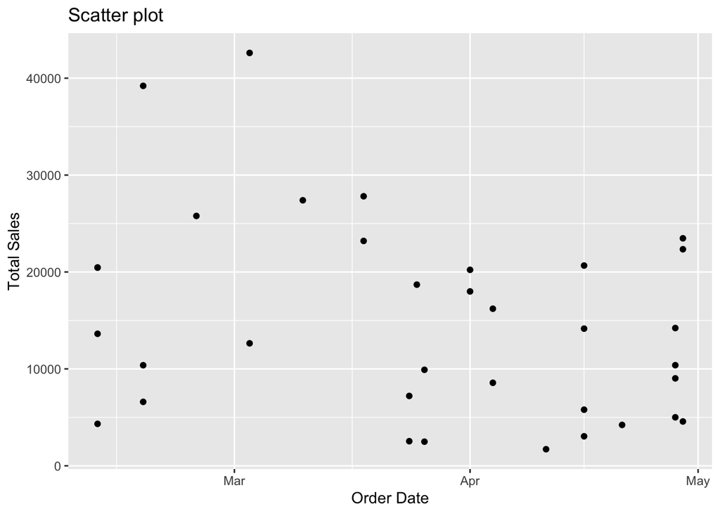

```r
# Create a scatter plot
ggplot(data = df_sales_by_day, aes(x = ORDERDATE, y = TotalSales)) +
  geom_point() +
  labs(title = "Scatter plot", x = "Order Date", y = "Total Sales")
```

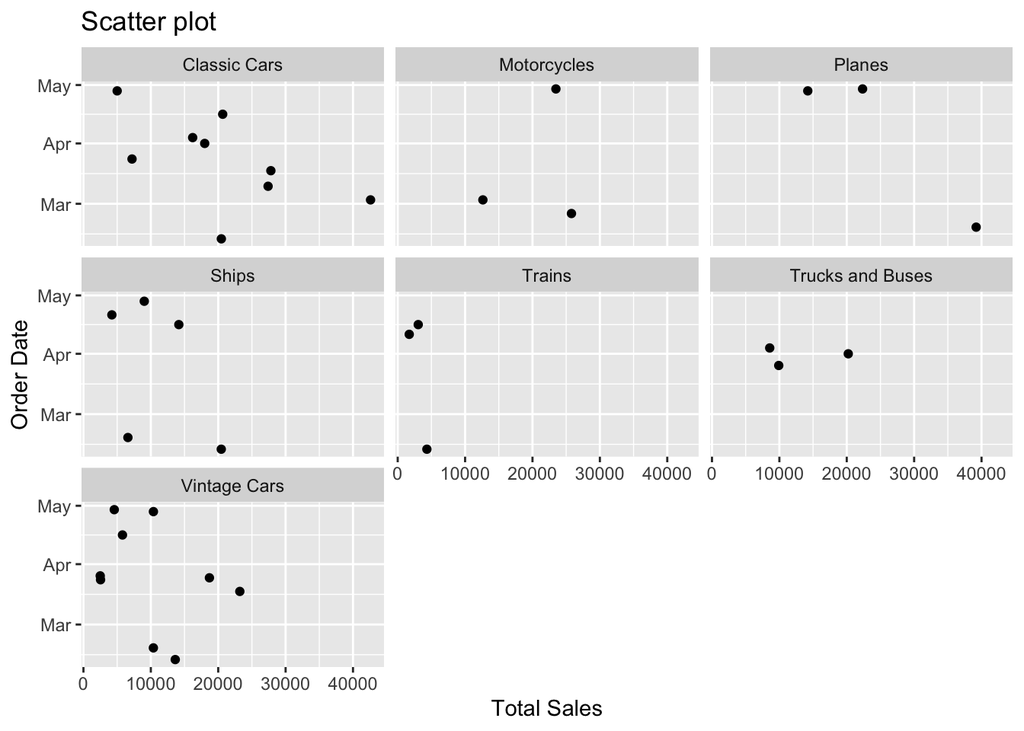

```r
# Create a scatter plot with compare on product lines
ggplot(data = df_sales_by_day, aes(x = ORDERDATE, y = TotalSales)) +
  geom_point() +
  facet_wrap(~PRODUCTLINE) +
  coord_flip() +
  labs(title = "Scatter plot", x = "Order Date", y = "Total Sales")
```

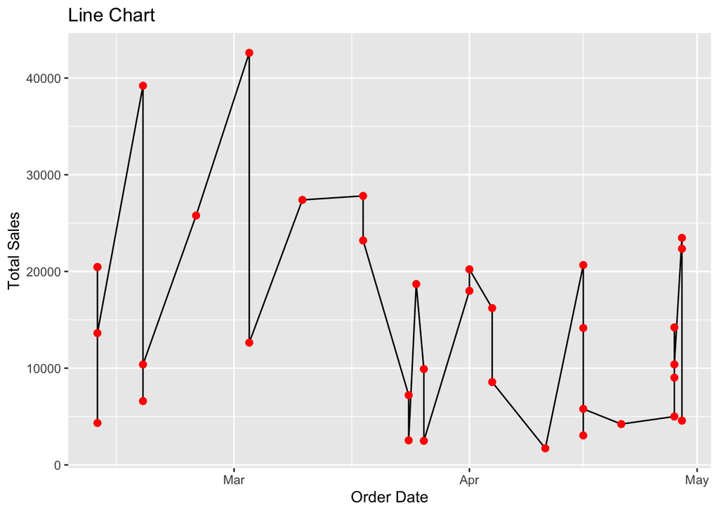

```r
# Create a line chart with red color data point
ggplot(data = df_sales_by_day, aes(x = ORDERDATE, y = TotalSales)) +
  geom_line() +
  geom_point(size=2, color ="red") +
  labs(title = "Line Chart", x = "Order Date", y = "Total Sales")
```

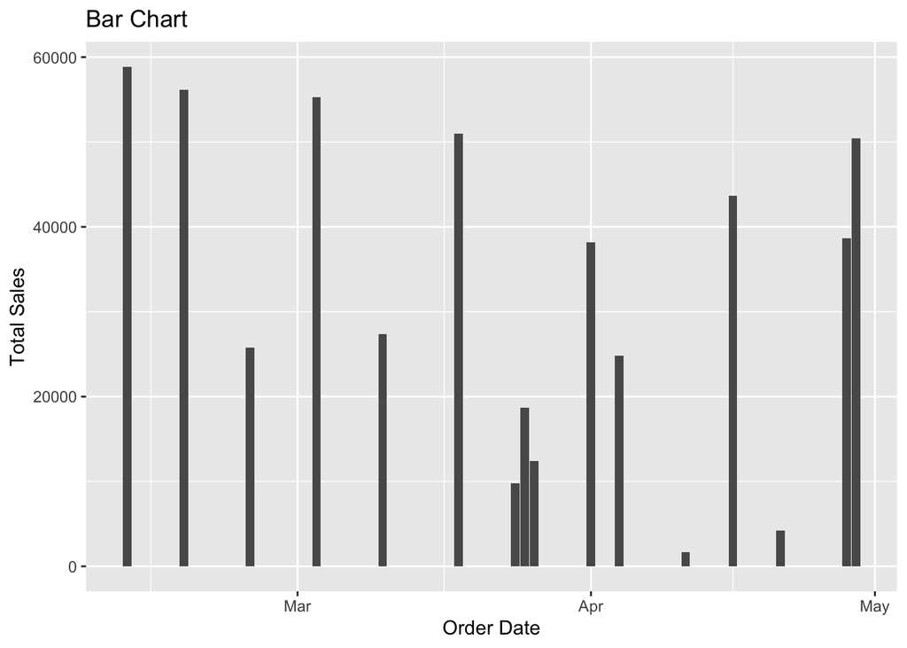

```r
# Create a bar chart
ggplot(data = df_sales_by_day, aes(x = ORDERDATE, y = TotalSales)) +
  geom_bar(stat = "identity") +
  labs(title = "Bar Chart", x = "Order Date", y = "Total Sales")
```

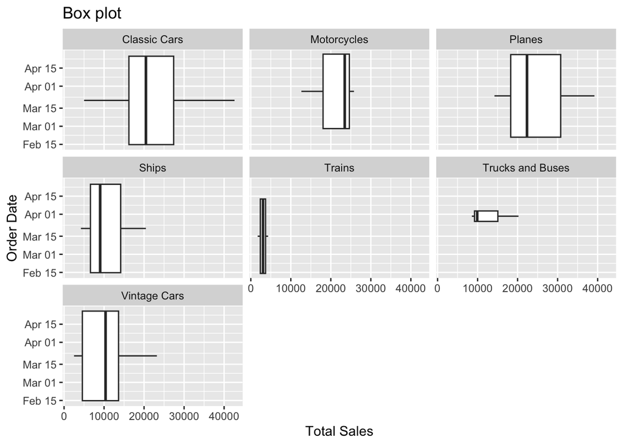

```r
# Create a box plot on different product lines
ggplot(data = df_sales_by_day, aes(x = ORDERDATE, y = TotalSales)) +
  geom_boxplot() +
  facet_wrap(~PRODUCTLINE) +
  coord_flip() +
  labs(title = "Box plot", x = "Order Date", y = "Total Sales")
```

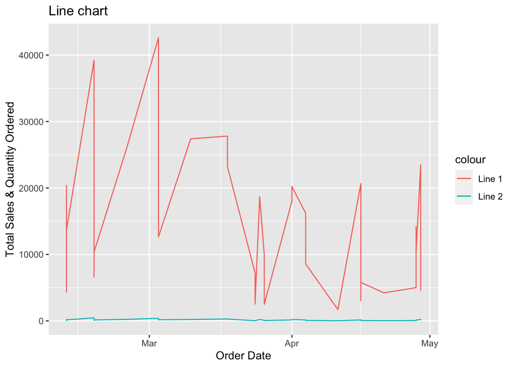

```r
# Create a line chart with 2 lines and different colors
ggplot(data = df_sales_by_day, aes(x = ORDERDATE)) +
  geom_line(aes(y = TotalSales,  color = "Line 1")) +
  geom_line(aes(y = TotalQuantityOrdered, color = "Line 2")) +
  labs(title = "Line chart", x = "Order Date", y = "Total Sales & Quantity Ordered")
```